Question No.1

Importing Data

```python
# Necessary libraries
import warnings
import numpy as np
import pandas as pd
import seaborn as sns
import matplotlib.pyplot as plt
from sklearn.model_selection import GridSearchCV, cross_validate, validation_curve
from matplotlib import pyplot as plt
from sklearn.ensemble import GradientBoostingClassifier
from sklearn.metrics import classification_report, roc_auc_score,accuracy_score
warnings.simplefilter(action='ignore', category=Warning)
from sklearn.model_selection import learning_curve
```

```python
df = pd.read_csv(r"C:\Users\HP\Downloads\ionosphere.csv")
```

```python
df.head(3)
```

|  | a01 | a02 | a03 | a04 | a05 | a06 | a07 | a08 | a09 | a10 | ... | a26 | a27 | a28 | a29 | a30 | a31 | a32 | a33 | a34 | class |
| --- | --- | --- | --- | --- | --- | --- | --- | --- | --- | --- | --- | --- | --- | --- | --- | --- | --- | --- | --- | --- | --- |
| 0 | 1 | 0 | 0.99539 | -0.05889 | 0.85243 | 0.02306 | 0.83398 | -0.37708 | 1.00000 | 0.03760 | ... | -0.51171 | 0.41078 | -0.46168 | 0.21266 | -0.34090 | 0.42267 | -0.54487 | 0.18641 | -0.45300 | g |
| 1 | 1 | 0 | 1.00000 | -0.18829 | 0.93035 | -0.36156 | -0.10868 | -0.93597 | 1.00000 | -0.04549 | ... | -0.26569 | -0.20468 | -0.18401 | -0.19040 | -0.11593 | -0.16626 | -0.06288 | -0.13738 | -0.02447 | b |
| 2 | 1 | 0 | 1.00000 | -0.03365 | 1.00000 | 0.00485 | 1.00000 | -0.12062 | 0.88965 | 0.01198 | ... | -0.40220 | 0.58984 | -0.22145 | 0.43100 | -0.17365 | 0.60436 | -0.24180 | 0.56045 | -0.38238 | g |

3 rows × 35 columns

EDA

```python
df.info()
```

```
<class 'pandas.core.frame.DataFrame'>
RangeIndex: 351 entries, 0 to 350
Data columns (total 35 columns):
 #   Column  Non-Null Count  Dtype
---  ------  --------------  -----
 0   a01     351 non-null    int64
 1   a02     351 non-null    int64
 2   a03     351 non-null    float64
 3   a04     351 non-null    float64
 4   a05     351 non-null    float64
 5   a06     351 non-null    float64
 6   a07     351 non-null    float64
 7   a08     351 non-null    float64
 8   a09     351 non-null    float64
 9   a10     351 non-null    float64
```

[output cut: 27 more lines]

```python
df.duplicated().any()
```

```
True
```

```python
# Check for duplicate rows
duplicates = df[df.duplicated()]

# Number of duplicate rows
num_duplicates = duplicates.shape[0]

print(f"Number of duplicate rows: {num_duplicates}")

# Display the duplicate rows (if any)
print("Duplicate rows:")
print(duplicates)
```

[output not shown]

```python
# Remove duplicate rows
df_cleaned = df.drop_duplicates()

# Verify that duplicates are removed
num_duplicates_after = df_cleaned.duplicated().sum()
print(f"Number of duplicate rows after removal: {num_duplicates_after}")
data = df_cleaned
# Optionally, check the cleaned DataFrame
print("Cleaned DataFrame:")
data.head(3)
```

```
Number of duplicate rows after removal: 0
Cleaned DataFrame:
```

[output not shown]

3 rows × 35 columns

Pre-Processing & Data Separation

```python
from sklearn.preprocessing import LabelEncoder

# Initialize the LabelEncoder
label_encoder = LabelEncoder()

# Fit and transform the 'class' column
data["class"] = label_encoder.fit_transform(data["class"])

# Print unique values for verification
print("Unique values in 'class' after encoding:", data["class"].unique())
```

```
Unique values in 'class' after encoding: [1 0]
```

```python
from sklearn.model_selection import train_test_split
y = df["class"] # dependent(target) variable
X = df.drop(["class"], axis=1) # independent variables

# Split the data into training and testing sets
X_train, X_test, y_train, y_test = train_test_split(X, y, test_size=0.2, random_state=42)
```

Hypermeter Tunning

```python
# Define the combined parameter distributions for RandomizedSearchCV
param_dist_combined = {
    'n_estimators': [100, 200],  # Number of boosting stages
    'learning_rate': [0.07, 0.08, 0.01],  # Learning rate (step size)
    'max_depth': [3, 4, 5],  # Maximum depth of the trees
    'subsample': [0.5, 0.6, 0.8],  # Fraction of samples used for fitting each base learner
    'min_samples_split': list(range(12, 16)),  # Minimum samples required to split an internal node
    'min_samples_leaf': list(range(14, 19)),  # Minimum samples required to be at a leaf node
    'max_features': [10, 'sqrt', 'log2']  # Number of features to consider when looking for the best split
}
```

```python
# Initialize the Gradient Boosting Classifier
gbm = GradientBoostingClassifier()
```

Model Building

```python
# Initialize GridSearchCV
grid_search_combined = GridSearchCV(estimator=gbm,
                                    param_grid=param_dist_combined,
                                    scoring='accuracy',
                                    cv=5,  # 5-fold cross-validation
                                    n_jobs=-1,  # Use all available cores
                                    verbose=1,  # Print progress
                                    return_train_score=True)

# Fit the grid search to the data
grid_search_combined.fit(X_train, y_train)
```

```
Fitting 5 folds for each of 3240 candidates, totalling 16200 fits
```

```
GridSearchCV(cv=5, estimator=GradientBoostingClassifier(), n_jobs=-1,
             param_grid={'learning_rate': [0.07, 0.08, 0.01],
                         'max_depth': [3, 4, 5],
                         'max_features': [10, 'sqrt', 'log2'],
                         'min_samples_leaf': [14, 15, 16, 17, 18],
                         'min_samples_split': [12, 13, 14, 15],
                         'n_estimators': [100, 200],
                         'subsample': [0.5, 0.6, 0.8]},
             return_train_score=True, scoring='accuracy', verbose=1)
```

```python
# Get the best parameters from grid search
best_params_grid = grid_search_combined.best_params_
print(f"Best Parameters from Grid Search: {best_params_grid}")

# Get the best model from grid search
best_gbm_grid = grid_search_combined.best_estimator_

# Predict and evaluate
y_pred_gbm_grid = best_gbm_grid.predict(X_test)
accuracy_gbm_grid = accuracy_score(y_test, y_pred_gbm_grid)
print(f"Accuracy of the best GBM model from Grid Search: {accuracy_gbm_grid:.4f}")
```

```
Best Parameters from Grid Search: {'learning_rate': 0.08, 'max_depth': 3, 'max_features': 10, 'min_samples_leaf': 15, 'min_samples_split': 13, 'n_estimators': 200, 'subsample': 0.8}
Accuracy of the best GBM model from Grid Search: 0.9296
```

Evaluation

```python
# Print classification report and confusion matrix
print("Classification Report:")
classification_report(y_test, y_pred_gbm_grid)
# Create a classification report dataframe
report_df = pd.DataFrame(classification_report(y_test, y_pred_gbm_grid, output_dict=True)).transpose()
report_df
```

```
Classification Report:
```

|  | precision | recall | f1-score | support |
| --- | --- | --- | --- | --- |
| 0 | 0.960000 | 0.857143 | 0.905660 | 28.000000 |
| 1 | 0.913043 | 0.976744 | 0.943820 | 43.000000 |
| accuracy | 0.929577 | 0.929577 | 0.929577 | 0.929577 |
| macro avg | 0.936522 | 0.916944 | 0.924740 | 71.000000 |
| weighted avg | 0.931562 | 0.929577 | 0.928771 | 71.000000 |

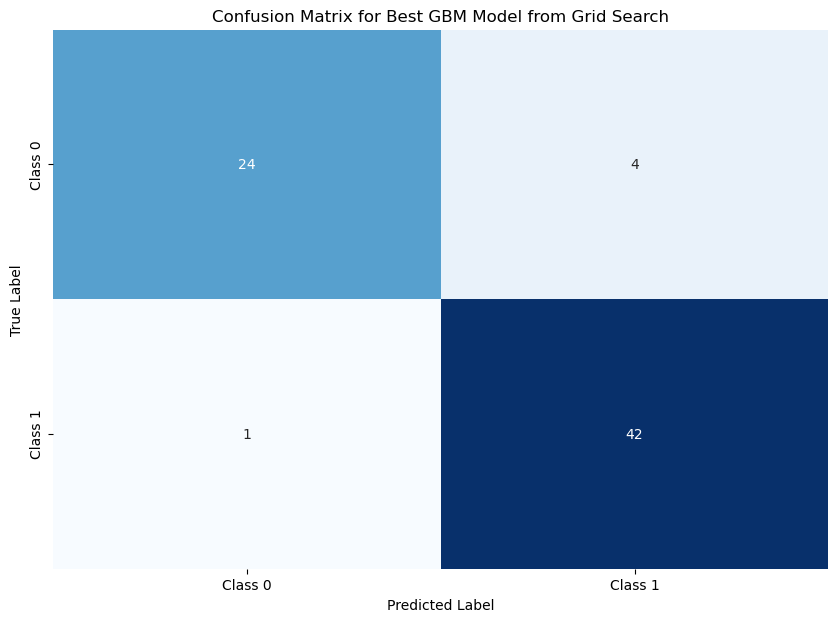

```python
# Compute confusion matrix
conf_matrix = confusion_matrix(y_test, y_pred_gbm_grid)

# Plot confusion matrix
plt.figure(figsize=(10, 7))
sns.heatmap(conf_matrix, annot=True, fmt='d', cmap='Blues', cbar=False,
            xticklabels=['Class 0', 'Class 1'], yticklabels=['Class 0', 'Class 1'])
plt.title('Confusion Matrix for Best GBM Model from Grid Search')
plt.xlabel('Predicted Label')
plt.ylabel('True Label')
plt.show()
```

```python
# Create a confusion matrix dataframe
conf_matrix_df = pd.DataFrame(confusion_matrix(y_test, y_pred_gbm_grid))
conf_matrix_df
```

|  | 0 | 1 |
| --- | --- | --- |
| 0 | 24 | 4 |
| 1 | 1 | 42 |

Evaluation Plotting

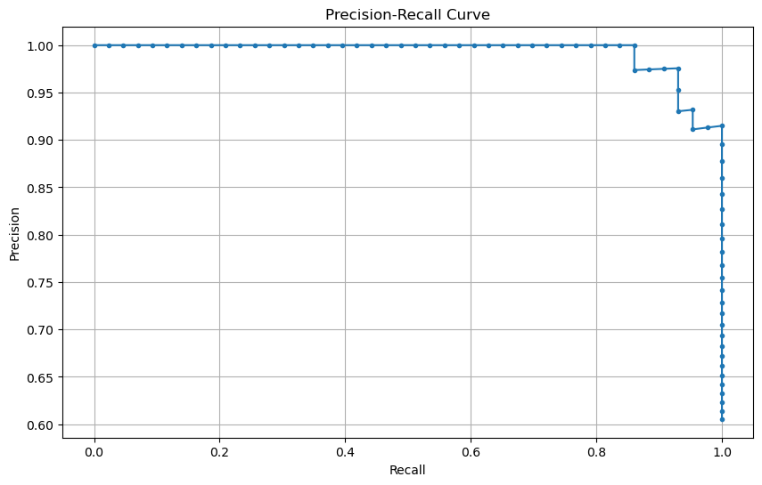

```python
from sklearn.metrics import precision_recall_curve

# Compute precision-recall pairs for different probability thresholds
y_probs = best_gbm_grid.predict_proba(X_test)[:, 1]
precision, recall, thresholds = precision_recall_curve(y_test, y_probs)

# Plot Precision-Recall curve
plt.figure(figsize=(10, 6))
plt.plot(recall, precision, marker='.')
plt.title('Precision-Recall Curve')
plt.xlabel('Recall')
plt.ylabel('Precision')
plt.grid()
plt.show()
```

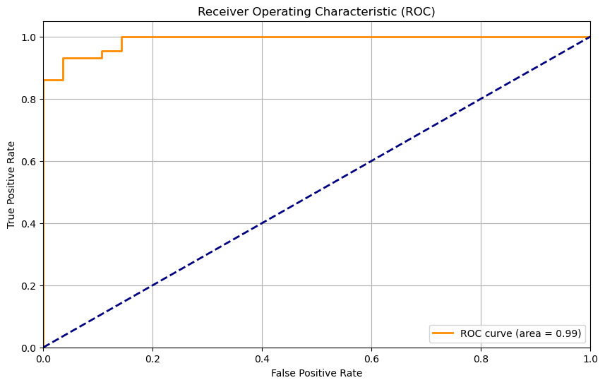

```python
from sklearn.metrics import roc_curve, auc

# Compute ROC curve and ROC area for each class
fpr, tpr, _ = roc_curve(y_test, y_probs)
roc_auc = auc(fpr, tpr)

# Plot ROC curve
plt.figure(figsize=(10, 6))
plt.plot(fpr, tpr, color='darkorange', lw=2, label='ROC curve (area = %0.2f)' % roc_auc)
plt.plot([0, 1], [0, 1], color='navy', lw=2, linestyle='--')
plt.xlim([0.0, 1.0])
plt.ylim([0.0, 1.05])
plt.xlabel('False Positive Rate')
plt.ylabel('True Positive Rate')
plt.title('Receiver Operating Characteristic (ROC)')
plt.legend(loc='lower right')
plt.grid()
plt.show()
```

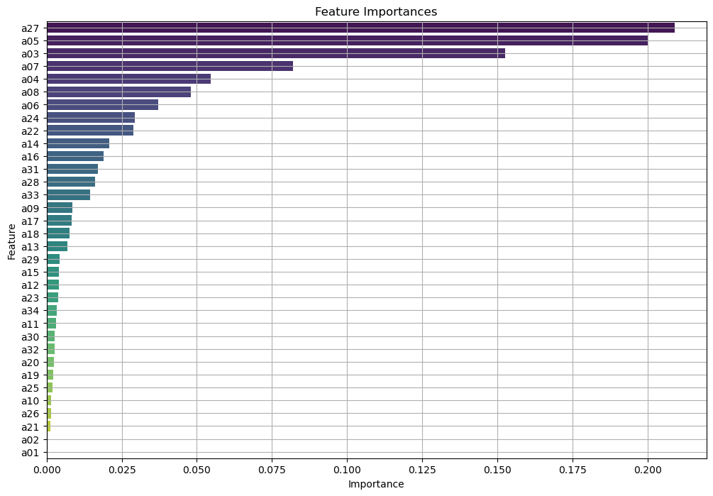

```python
# Get feature importances
importances = best_gbm_grid.feature_importances_
feature_names = X_train.columns

# Create a DataFrame for plotting
feature_importance_df = pd.DataFrame({'Feature': feature_names, 'Importance': importances})
feature_importance_df = feature_importance_df.sort_values(by='Importance', ascending=False)

# Plot feature importances
plt.figure(figsize=(12, 8))
sns.barplot(x='Importance', y='Feature', data=feature_importance_df, palette='viridis')
plt.title('Feature Importances')
plt.grid()
plt.show()
```

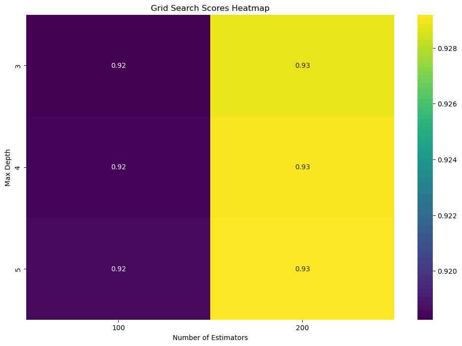

```python
# Extract results from GridSearchCV
results = pd.DataFrame(grid_search_combined.cv_results_)

# Pivot the DataFrame for heatmap
heatmap_data = results.pivot_table(index='param_max_depth', columns='param_n_estimators', values='mean_test_score')

# Plot heatmap
plt.figure(figsize=(12, 8))
sns.heatmap(heatmap_data, annot=True, cmap='viridis', fmt='.2f')
plt.title('Grid Search Scores Heatmap')
plt.xlabel('Number of Estimators')
plt.ylabel('Max Depth')
plt.show()
```

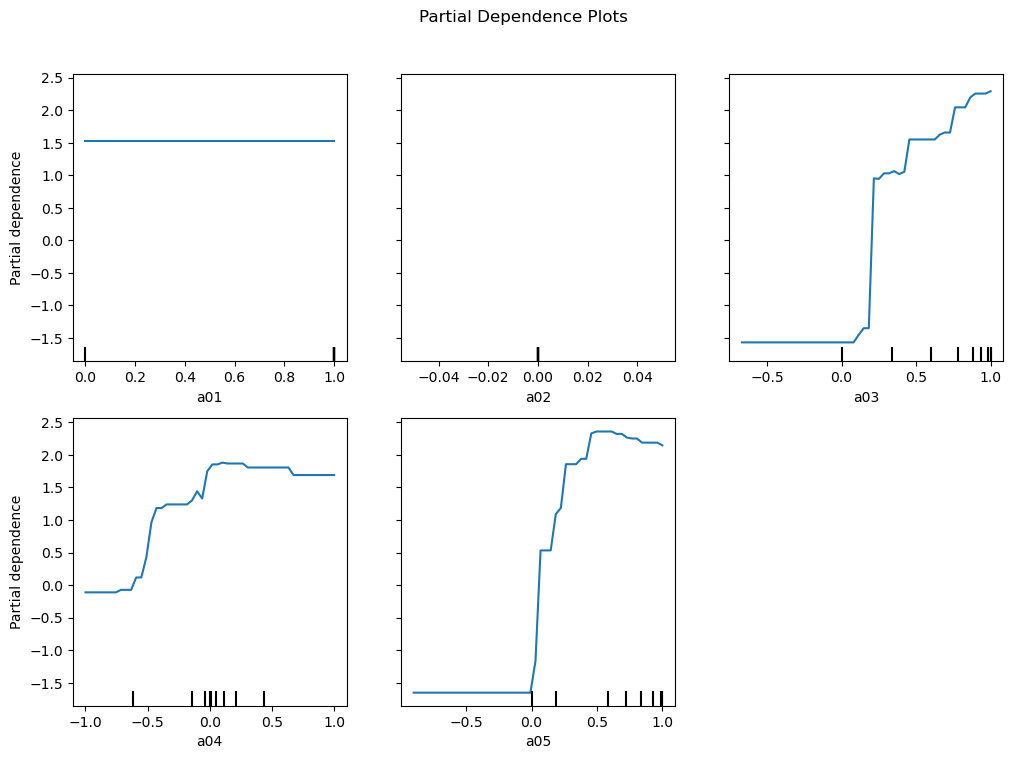

```python
from sklearn.inspection import PartialDependenceDisplay

# Plot partial dependence
fig, ax = plt.subplots(figsize=(12, 8))
features = [0, 1, 2, 3, 4]  # List the indices of the features to plot
PartialDependenceDisplay.from_estimator(best_gbm_grid, X_train, features, ax=ax, grid_resolution=50)
plt.suptitle('Partial Dependence Plots')
plt.subplots_adjust(top=0.9)  # Adjust title position
plt.show()
```

Question No.2

```python
# Importing necessary libraries
import numpy as np
import pandas as pd
import matplotlib.pyplot as plt
import seaborn as sns

import tensorflow as tf
from tensorflow.keras.models import Sequential
from tensorflow.keras.layers import Dense, GRU
from tensorflow.keras.callbacks import EarlyStopping
from sklearn.preprocessing import MinMaxScaler
from tensorflow.keras.preprocessing.sequence import TimeseriesGenerator
```

```python
# Load the dataset
dataset_path = r"C:\Users\HP\Downloads\RSCCASN.csv"  # Replace with your dataset path
sales_data = pd.read_csv(dataset_path, parse_dates=True, index_col='DATE')
sales_data.head(3)
```

| DATE | SALES |
| --- | --- |
| 1992-01-01 | 6938 |
| 1992-02-01 | 7524 |
| 1992-03-01 | 8475 |

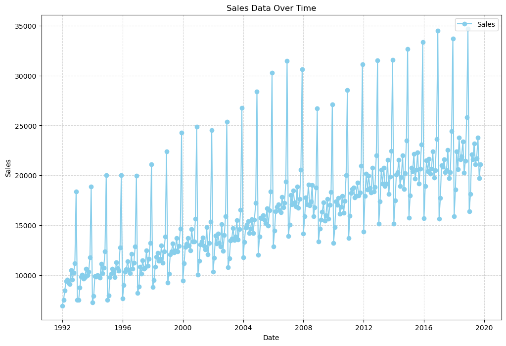

```python
import matplotlib.pyplot as plt
import matplotlib.dates as mdates

# Plot the data
fig, ax = plt.subplots(figsize=(12, 8))

# Plot the sales data with a line plot
ax.plot(sales_data.index, sales_data.values, label='Sales', marker='o', linestyle='-', color='skyblue')

# Set title and labels
ax.set_title('Sales Data Over Time')
ax.set_xlabel('Date')
ax.set_ylabel('Sales')

# Add gridlines
ax.grid(True, which='major', axis='both', linestyle='--', alpha=0.5)

# Add a legend
ax.legend(loc='upper right')

# Show the plot
plt.show()
```

```python
# Data Preprocessing
scaler = MinMaxScaler()
scaled_sales = scaler.fit_transform(sales_data)

# Generate time series sequences
length = 12
train_size = int(len(scaled_sales) * 0.8)
test_size = len(scaled_sales) - train_size
train, test = scaled_sales[0:train_size], scaled_sales[train_size:len(scaled_sales)]

train_generator = TimeseriesGenerator(train, train, length=length, batch_size=1)
validation_generator = TimeseriesGenerator(test, test, length=length, batch_size=1)
```

Model Building & Training

```python
from keras.models import Sequential
from keras.layers import GRU, Dense, Dropout, Input

# Define the input shape
input_shape = (length, n_features)

# Build the GRU model
model = Sequential()
model.add(Input(shape=input_shape))  # Add an Input layer to specify the input shape
model.add(GRU(units=128, activation='relu', return_sequences=True))
model.add(Dropout(0.2))
model.add(GRU(units=64, activation='relu'))
model.add(Dropout(0.2))
model.add(Dense(1))

model.compile(optimizer=Adam(learning_rate=0.001), loss='mse', metrics=['mae'])

print(model.summary())
```

```
Model: "sequential_2"
```

```
┏━━━━━━━━━━━━━━━━━━━━━━━━━━━━━━━━━━━━━━┳━━━━━━━━━━━━━━━━━━━━━━━━━━━━━┳━━━━━━━━━━━━━━━━━┓
┃ Layer (type)                         ┃ Output Shape                ┃         Param # ┃
┡━━━━━━━━━━━━━━━━━━━━━━━━━━━━━━━━━━━━━━╇━━━━━━━━━━━━━━━━━━━━━━━━━━━━━╇━━━━━━━━━━━━━━━━━┩
│ gru_4 (GRU)                          │ (None, 12, 128)             │          50,304 │
├──────────────────────────────────────┼─────────────────────────────┼─────────────────┤
│ dropout_4 (Dropout)                  │ (None, 12, 128)             │               0 │
├──────────────────────────────────────┼─────────────────────────────┼─────────────────┤
│ gru_5 (GRU)                          │ (None, 64)                  │          37,248 │
├──────────────────────────────────────┼─────────────────────────────┼─────────────────┤
│ dropout_5 (Dropout)                  │ (None, 64)                  │               0 │
├──────────────────────────────────────┼─────────────────────────────┼─────────────────┤
│ dense_2 (Dense)                      │ (None, 1)                   │              65 │
└──────────────────────────────────────┴─────────────────────────────┴─────────────────┘
```

```
 Total params: 87,617 (342.25 KB)
```

```
 Trainable params: 87,617 (342.25 KB)
```

```
 Non-trainable params: 0 (0.00 B)
```

```
None
```

```python
import warnings
warnings.filterwarnings("ignore", category=UserWarning, module='keras')
```

```python
# Define early stopping and learning rate reduction
early_stop = EarlyStopping(monitor='val_loss', patience=10, min_delta=0.001)
reduce_lr = ReduceLROnPlateau(monitor='val_loss', patience=5, min_delta=0.001, factor=0.5)

# Train the model
history = model.fit(train_generator,
                    epochs=30,
                    validation_data=validation_generator,
                    callbacks=[early_stop, reduce_lr],
                    verbose=1)
```

```
255/255 ━━━━━━━━━━━━━━━━━━━━ 5s 21ms/step - loss: 0.0014 - mae: 0.0279 - val_loss: 0.0011 - val_mae: 0.0240 - learning_rate: 7.8125e-06
255/255 ━━━━━━━━━━━━━━━━━━━━ 5s 20ms/step - loss: 0.0012 - mae: 0.0252 - val_loss: 0.0011 - val_mae: 0.0242 - learning_rate: 7.8125e-06
255/255 ━━━━━━━━━━━━━━━━━━━━ 5s 21ms/step - loss: 0.0021 - mae: 0.0287 - val_loss: 0.0011 - val_mae: 0.0243 - learning_rate: 7.8125e-06
255/255 ━━━━━━━━━━━━━━━━━━━━ 6s 22ms/step - loss: 0.0015 - mae: 0.0286 - val_loss: 0.0011 - val_mae: 0.0238 - learning_rate: 7.8125e-06
255/255 ━━━━━━━━━━━━━━━━━━━━ 6s 21ms/step - loss: 0.0016 - mae: 0.0287 - val_loss: 0.0011 - val_mae: 0.0239 - learning_rate: 7.8125e-06
255/255 ━━━━━━━━━━━━━━━━━━━━ 6s 23ms/step - loss: 0.0013 - mae: 0.0257 - val_loss: 0.0010 - val_mae: 0.0238 - learning_rate: 7.8125e-06
255/255 ━━━━━━━━━━━━━━━━━━━━ 6s 22ms/step - loss: 0.0014 - mae: 0.0271 - val_loss: 0.0010 - val_mae: 0.0238 - learning_rate: 3.9063e-06
255/255 ━━━━━━━━━━━━━━━━━━━━ 6s 22ms/step - loss: 0.0015 - mae: 0.0277 - val_loss: 0.0010 - val_mae: 0.0238 - learning_rate: 3.9063e-06
255/255 ━━━━━━━━━━━━━━━━━━━━ 5s 20ms/step - loss: 0.0011 - mae: 0.0238 - val_loss: 0.0010 - val_mae: 0.0237 - learning_rate: 3.9063e-06
255/255 ━━━━━━━━━━━━━━━━━━━━ 5s 21ms/step - loss: 0.0015 - mae: 0.0282 - val_loss: 0.0010 - val_mae: 0.0238 - learning_rate: 3.9063e-06
255/255 ━━━━━━━━━━━━━━━━━━━━ 5s 21ms/step - loss: 0.0018 - mae: 0.0293 - val_loss: 0.0010 - val_mae: 0.0240 - learning_rate: 3.9063e-06
```

Evaluation

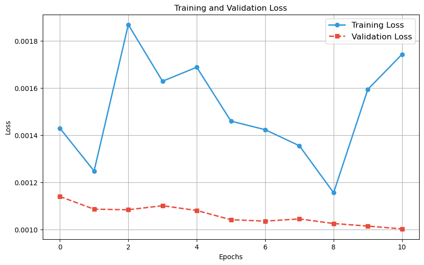

```python
# Plot training & validation loss
losses = pd.DataFrame(history.history)
plt.figure(figsize=(10, 6))
plt.plot(losses.index, losses['loss'], label='Training Loss', color='#3498db', linestyle='-', linewidth=2, marker='o')
plt.plot(losses.index, losses['val_loss'], label='Validation Loss', color='#e74c3c', linestyle='--', linewidth=2, marker='s')
plt.title("Training and Validation Loss")
plt.xlabel("Epochs")
plt.ylabel("Loss")
plt.legend(loc='upper right', fontsize=12)
plt.grid(True)
plt.show()
```

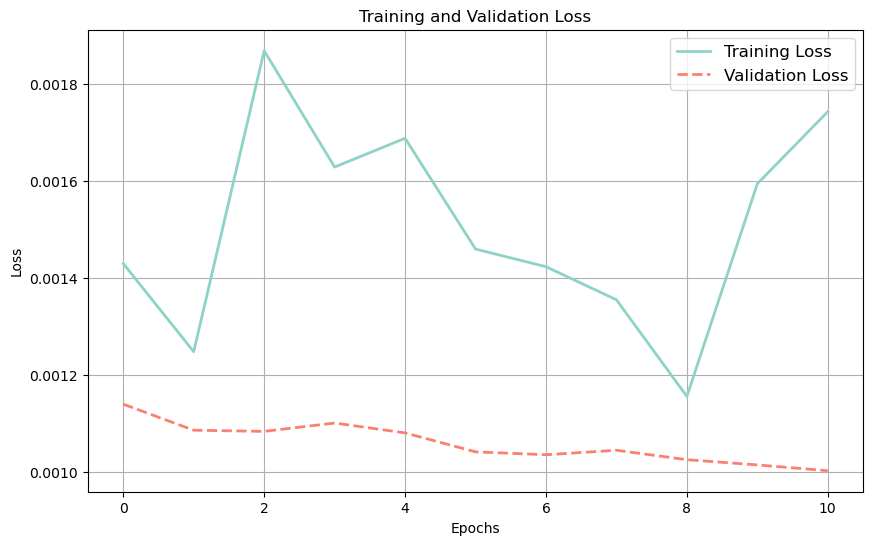

```
55/55 ━━━━━━━━━━━━━━━━━━━━ 1s 8ms/step
```

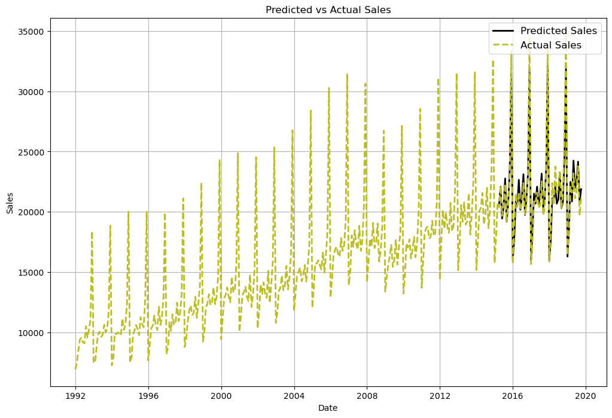

```python
# Plot the training and validation loss
losses = pd.DataFrame(history.history)
plt.figure(figsize=(10, 6))
plt.plot(losses['loss'], label='Training Loss', color='#8dd3c7', linestyle='-', linewidth=2)  # light blue
plt.plot(losses['val_loss'], label='Validation Loss', color='#fb8072', linestyle='--', linewidth=2)  # reddish pink
plt.title('Training and Validation Loss')
plt.xlabel('Epochs')
plt.ylabel('Loss')
plt.legend(loc='upper right', fontsize=12)
plt.grid(True)  # add grid lines
plt.show()

# Predicting on the test set
predictions = model.predict(validation_generator)

# Inverse scaling the predictions
predictions = scaler.inverse_transform(predictions)

# Plot the predictions vs actual values
plt.figure(figsize=(12, 8))
plt.plot(sales_data.index[-len(predictions):], predictions, label='Predicted Sales', color='#000000', linestyle='-', linewidth=2)  # orange
plt.plot(sales_data.index, sales_data.values, label='Actual Sales', color='#bcbd22', linestyle='--', linewidth=2)  # yellowish green
plt.title('Predicted vs Actual Sales')
plt.xlabel('Date')
plt.ylabel('Sales')
plt.legend(loc='upper right', fontsize=12)
plt.grid(True)  # add grid lines
plt.show()
```

Predictions

```python
# Make predictions
predictions = model.predict(validation_generator)
predicted_sales = scaler.inverse_transform(predictions)

# Inverse scaling the original test set to get actual sales in original scale
actual_sales = scaler.inverse_transform(test[length:])

# Create a DataFrame to compare actual and predicted sales
sales_comparison_df = pd.DataFrame(data={
    'Date': sales_data.index[-len(predictions):],  # Dates corresponding to the predictions
    'Actual Sales': actual_sales.flatten(),         # Flatten to ensure 1D array
    'Predicted Sales': predicted_sales.flatten()    # Flatten to ensure 1D array
})

sales_comparison_df.head()
```

```
55/55 ━━━━━━━━━━━━━━━━━━━━ 1s 8ms/step
```

|  | Date | Actual Sales | Predicted Sales |
| --- | --- | --- | --- |
| 0 | 2015-04-01 | 20389.0 | 20603.150391 |
| 1 | 2015-05-01 | 22145.0 | 22080.652344 |
| 2 | 2015-06-01 | 19667.0 | 19446.619141 |
| 3 | 2015-07-01 | 20564.0 | 20423.433594 |
| 4 | 2015-08-01 | 22314.0 | 22769.865234 |

Question no.7

Importing Libraries

```python
import os
from tqdm import tqdm
import pickle
import scipy
import pandas as pd
import sys
import numpy as np
import matplotlib.pyplot as plt
%matplotlib inline
import librosa #Python package for music & audio files
import librosa.display
import librosa.display as lplt
from IPython.display import Audio
from sklearn.preprocessing import StandardScaler
from sklearn.preprocessing import LabelEncoder
from sklearn.preprocessing import normalize
from sklearn.feature_selection import RFECV,mutual_info_regression
from sklearn.metrics import confusion_matrix, accuracy_score,classification_report
from sklearn.model_selection import train_test_split, cross_val_score
from sklearn.decomposition import PCA
import tensorflow as tf
from tensorflow import keras
```

```python
df = pd.read_csv(r"C:\Users\HP\Downloads\Music\features_3_sec.csv")
```

Exploratory Data Analysis

```python
print("Dataset has",df.shape)
print("Count of Positive and Negative samples")
df.label.value_counts().reset_index()
```

```
Dataset has (9990, 60)
Count of Positive and Negative samples
```

|  | label | count |
| --- | --- | --- |
| 0 | blues | 1000 |
| 1 | jazz | 1000 |
| 2 | metal | 1000 |
| 3 | pop | 1000 |
| 4 | reggae | 1000 |
| 5 | disco | 999 |
| 6 | classical | 998 |
| 7 | hiphop | 998 |
| 8 | rock | 998 |
| 9 | country | 997 |

```python
# General path to the directory
audio = r"C:\Users\HP\Downloads\Music\genres_original"

# List the contents of the directory
print(list(os.listdir(audio)))
```

```
['blues', 'classical', 'country', 'disco', 'hiphop', 'jazz', 'metal', 'pop', 'reggae', 'rock']
```

```python
def calculate_zero_crossings(audio_path):
    data, sr = librosa.load(audio_path)
    zero_crossings = librosa.zero_crossings(data, pad=False)
    zero_crossing_count = sum(zero_crossings)
    return zero_crossing_count

for idx, (audio_path, genre) in enumerate(audio_files):
    zero_crossing_count = calculate_zero_crossings(audio_path)
    print(f"Genre: {genre} | Song {idx + 1} | Zero-crossings: {zero_crossing_count}")
```

```
Genre: BLUES | Song 1 | Zero-crossings: 37139
Genre: ROCK | Song 2 | Zero-crossings: 93137
Genre: CLASSICAL | Song 3 | Zero-crossings: 82418
Genre: COUNTRY | Song 4 | Zero-crossings: 34791
Genre: DISCO | Song 5 | Zero-crossings: 94903
Genre: HIPHOP | Song 6 | Zero-crossings: 66772
Genre: JAZZ | Song 7 | Zero-crossings: 28391
Genre: METAL | Song 8 | Zero-crossings: 58458
Genre: POP | Song 9 | Zero-crossings: 63588
Genre: REGGAE | Song 10 | Zero-crossings: 66965
```

Data Separation

```python
data = df.drop(columns = 'filename', axis =1)

data.head(3)
```

|  | length | chroma_stft_mean | chroma_stft_var | rms_mean | rms_var | spectral_centroid_mean | spectral_centroid_var | spectral_bandwidth_mean | spectral_bandwidth_var | rolloff_mean | ... | mfcc16_var | mfcc17_mean | mfcc17_var | mfcc18_mean | mfcc18_var | mfcc19_mean | mfcc19_var | mfcc20_mean | mfcc20_var | label |
| --- | --- | --- | --- | --- | --- | --- | --- | --- | --- | --- | --- | --- | --- | --- | --- | --- | --- | --- | --- | --- | --- |
| 0 | 66149 | 0.335406 | 0.091048 | 0.130405 | 0.003521 | 1773.065032 | 167541.630869 | 1972.744388 | 117335.771563 | 3714.560359 | ... | 39.687145 | -3.241280 | 36.488243 | 0.722209 | 38.099152 | -5.050335 | 33.618073 | -0.243027 | 43.771767 | blues |
| 1 | 66149 | 0.343065 | 0.086147 | 0.112699 | 0.001450 | 1816.693777 | 90525.690866 | 2010.051501 | 65671.875673 | 3869.682242 | ... | 64.748276 | -6.055294 | 40.677654 | 0.159015 | 51.264091 | -2.837699 | 97.030830 | 5.784063 | 59.943081 | blues |
| 2 | 66149 | 0.346815 | 0.092243 | 0.132003 | 0.004620 | 1788.539719 | 111407.437613 | 2084.565132 | 75124.921716 | 3997.639160 | ... | 67.336563 | -1.768610 | 28.348579 | 2.378768 | 45.717648 | -1.938424 | 53.050835 | 2.517375 | 33.105122 | blues |

3 rows × 59 columns

```python
X= data.drop(columns = 'label', axis = 1)
y = data['label']
X_train, X_test, y_train, y_test = train_test_split(X, y, test_size=0.25, random_state=42)

# Example code to print the shapes of training and test datasets
print(f"Shape of X_train: {X_train.shape}")
print(f"Shape of y_train: {y_train.shape}")

# If you have test data, you can also print its shape
print(f"Shape of X_test: {X_test.shape}")
print(f"Shape of y_test: {y_test.shape}")
```

[output not shown]

Data Pre-Processing

```python
from sklearn.preprocessing import MinMaxScaler
X = data.drop(columns='label', axis=1)
y = data['label']



# Split the data
X_train, X_test, y_train, y_test = train_test_split(X, y, test_size=0.25, random_state=42)

# Print the shapes of training and test datasets
print(f"Shape of X_train: {X_train.shape}")
print(f"Shape of y_train: {y_train.shape}")
print(f"Shape of X_test: {X_test.shape}")
print(f"Shape of y_test: {y_test.shape}")

# Preprocess the data
min_max_scaler = MinMaxScaler()
standard_scaler = StandardScaler()

X_train_scaled = min_max_scaler.fit_transform(X_train)
X_test_scaled = min_max_scaler.transform(X_test)

# Convert categorical labels to numerical labels
le = LabelEncoder()
y_train_encoded = le.fit_transform(y_train)
y_test_encoded = le.transform(y_test)


# Create DataFrames for better visualization
df_X_train = pd.DataFrame(X_train_scaled, columns=[f'Feature_{i}' for i in range(X_train_scaled.shape[1])])
df_X_test = pd.DataFrame(X_test_scaled, columns=[f'Feature_{i}' for i in range(X_test_scaled.shape[1])])



# Display DataFrames
print("X_train DataFrame:")
print(df_X_train.head(3))

print("X_test DataFrame:")
print(df_X_test.head(3))
```

```
Shape of X_train: (7492, 58)
Shape of y_train: (7492,)
Shape of X_test: (2498, 58)
Shape of y_test: (2498,)
X_train DataFrame:
   Feature_0  Feature_1  Feature_2  Feature_3  Feature_4  Feature_5  \
0        0.0   0.498843   0.805987   0.371196   0.551076   0.393286
1        0.0   0.361430   0.803541   0.167361   0.082811   0.182938
2        0.0   0.237473   0.739628   0.357997   0.044447   0.312206

   Feature_6  Feature_7  Feature_8  Feature_9  ...  Feature_48  Feature_49  \
0   0.223845   0.650895   0.143128   0.489269  ...    0.404825    0.079578
1   0.063611   0.387566   0.160903   0.280369  ...    0.450167    0.114848
2   0.018988   0.548188   0.070365   0.412922  ...    0.420980    0.041430

   Feature_50  Feature_51  Feature_52  Feature_53  Feature_54  Feature_55  \
0    0.300923    0.075693    0.379182    0.070234    0.427659    0.019379
1    0.322456    0.062158    0.346475    0.025284    0.520680    0.026116
2    0.334236    0.058582    0.337534    0.044731    0.490291    0.045484

   Feature_56  Feature_57
0    0.353149    0.116224
1    0.377508    0.052141
2    0.504740    0.127744

[3 rows x 58 columns]
X_test DataFrame:
   Feature_0  Feature_1  Feature_2  Feature_3  Feature_4  Feature_5  \
0        0.0   0.449989   0.772012   0.204905   0.019575   0.190181
1        0.0   0.194069   0.652902   0.204730   0.028512   0.147884
2        0.0   0.371712   0.673366   0.297532   0.036694   0.367201

   Feature_6  Feature_7  Feature_8  Feature_9  ...  Feature_48  Feature_49  \
0   0.096897   0.432013   0.185317   0.276373  ...    0.547183    0.080034
1   0.010029   0.284852   0.023316   0.210476  ...    0.391525    0.035364
2   0.038280   0.500184   0.108157   0.459383  ...    0.485503    0.094528

   Feature_50  Feature_51  Feature_52  Feature_53  Feature_54  Feature_55  \
0    0.338559    0.093698    0.377247    0.020590    0.407529    0.019861
1    0.340800    0.041620    0.219801    0.017475    0.308786    0.039630
2    0.336853    0.046367    0.286379    0.062249    0.324580    0.034305

   Feature_56  Feature_57
0    0.447827    0.046999
1    0.297651    0.017285
2    0.444202    0.047434

[3 rows x 58 columns]
```

🎼 Harmonizing with Machine Learning: Model Building

[figure not shown]

### 1. Fully Connected Neural Network (Dense Network) 🤖

A **Fully Connected Neural Network (FCNN)**, or Dense Network, is a fundamental neural network architecture. This model consists of layers where each neuron in one layer is connected to every neuron in the next layer. This connectivity allows the network to learn complex patterns in the data, making it highly effective for various classification tasks.

- **Key Features**:
  - Dense layers with ReLU activation
  - Suitable for capturing complex patterns
  - Effective for various classification tasks

### 2. 1D Convolutional Neural Network (CNN) with Long Short-Term Memory (LSTM) 🌐

This hybrid model leverages the feature extraction capabilities of **Convolutional Neural Networks (CNNs)** and the sequential processing strengths of **Long Short-Term Memory (LSTM)** networks. The CNN layers capture local temporal patterns in the audio data, while the LSTM layers capture long-term dependencies, making this model particularly powerful for audio classification tasks.

- **Key Features**:
  - Combines CNN and LSTM for robust feature extraction
  - Captures both local and sequential patterns
  - Ideal for processing audio data

### Why These Models? 🤔

```python
def plotValidate(history):
    """
    Plot training and validation metrics with enhanced visualization.

    Parameters:
    history (tf.keras.callbacks.History): Training history returned from model.fit.
    """
    # Extract metrics from history
    metrics = history.history

    # Print the best validation accuracy
    print("Best Validation Accuracy:", max(metrics.get("val_accuracy", [0])))

    # Plot loss and accuracy
    plt.figure(figsize=(16, 8))

    # Colors for the plots
    color_train_accuracy = '#1f77b4'
    color_val_accuracy = '#ff7f0e'
    color_train_loss = '#2ca02c'
    color_val_loss = '#d62728'

    # Plot accuracy
    plt.subplot(1, 2, 1)
    plt.plot(metrics['accuracy'], color=color_train_accuracy, linestyle='-', marker='o', label='Training Accuracy')
    plt.plot(metrics['val_accuracy'], color=color_val_accuracy, linestyle='--', marker='x', label='Validation Accuracy')
    plt.title('Training and Validation Accuracy')
    plt.xlabel('Epochs')
    plt.ylabel('Accuracy')
    plt.legend()
    plt.grid(True)

    # Plot loss
    plt.subplot(1, 2, 2)
    plt.plot(metrics['loss'], color=color_train_loss, linestyle='-', marker='o', label='Training Loss')
    plt.plot(metrics['val_loss'], color=color_val_loss, linestyle='--', marker='x', label='Validation Loss')
    plt.title('Training and Validation Loss')
    plt.xlabel('Epochs')
    plt.ylabel('Loss')
    plt.legend()
    plt.grid(True)

    # Improve layout and show plots
    plt.tight_layout()
    plt.show()
```

Model-1: Fully Connected Neural Networks

```python
# Define the model
model = Sequential([
    Input(shape=(X_train.shape[1],)),
    Dense(1024, activation="relu", kernel_regularizer=tf.keras.regularizers.l2(0.01)),
    BatchNormalization(),
    Dropout(0.3),

    Dense(512, activation="relu", kernel_regularizer=tf.keras.regularizers.l2(0.01)),
    BatchNormalization(),
    Dropout(0.3),

    Dense(256, activation="relu", kernel_regularizer=tf.keras.regularizers.l2(0.01)),
    BatchNormalization(),
    Dropout(0.3),

    Dense(128, activation="relu", kernel_regularizer=tf.keras.regularizers.l2(0.01)),
    BatchNormalization(),
    Dropout(0.3),

    Dense(64, activation="relu", kernel_regularizer=tf.keras.regularizers.l2(0.01)),
    BatchNormalization(),
    Dropout(0.3),

    Dense(10, activation="softmax")
])

# Compile the model with a learning rate schedule
lr_schedule = tf.keras.optimizers.schedules.CosineDecay(initial_learning_rate=0.001, decay_steps=1000, alpha=0.1)
optimizer = tf.keras.optimizers.Adam(learning_rate=lr_schedule)

model.compile(optimizer=optimizer, loss="categorical_crossentropy", metrics=["accuracy"])

# Print the model summary
print(model.summary())

# Callbacks for early stopping and model checkpointing
early_stopping = EarlyStopping(monitor='val_loss', patience=10, restore_best_weights=True)
model_checkpoint = ModelCheckpoint('best_model.keras', monitor='val_loss', save_best_only=True)
```

```
Model: "sequential_1"
```

```
┏━━━━━━━━━━━━━━━━━━━━━━━━━━━━━━━━━━━━━━┳━━━━━━━━━━━━━━━━━━━━━━━━━━━━━┳━━━━━━━━━━━━━━━━━┓
┃ Layer (type)                         ┃ Output Shape                ┃         Param # ┃
┡━━━━━━━━━━━━━━━━━━━━━━━━━━━━━━━━━━━━━━╇━━━━━━━━━━━━━━━━━━━━━━━━━━━━━╇━━━━━━━━━━━━━━━━━┩
│ dense_6 (Dense)                      │ (None, 1024)                │          60,416 │
├──────────────────────────────────────┼─────────────────────────────┼─────────────────┤
│ batch_normalization_5                │ (None, 1024)                │           4,096 │
│ (BatchNormalization)                 │                             │                 │
├──────────────────────────────────────┼─────────────────────────────┼─────────────────┤
│ dropout_5 (Dropout)                  │ (None, 1024)                │               0 │
├──────────────────────────────────────┼─────────────────────────────┼─────────────────┤
│ dense_7 (Dense)                      │ (None, 512)                 │         524,800 │
├──────────────────────────────────────┼─────────────────────────────┼─────────────────┤
│ batch_normalization_6                │ (None, 512)                 │           2,048 │
│ (BatchNormalization)                 │                             │                 │
├──────────────────────────────────────┼─────────────────────────────┼─────────────────┤
│ dropout_6 (Dropout)                  │ (None, 512)                 │               0 │
├──────────────────────────────────────┼─────────────────────────────┼─────────────────┤
│ dense_8 (Dense)                      │ (None, 256)                 │         131,328 │
├──────────────────────────────────────┼─────────────────────────────┼─────────────────┤
│ batch_normalization_7                │ (None, 256)                 │           1,024 │
│ (BatchNormalization)                 │                             │                 │
├──────────────────────────────────────┼─────────────────────────────┼─────────────────┤
│ dropout_7 (Dropout)                  │ (None, 256)                 │               0 │
├──────────────────────────────────────┼─────────────────────────────┼─────────────────┤
│ dense_9 (Dense)                      │ (None, 128)                 │          32,896 │
├──────────────────────────────────────┼─────────────────────────────┼─────────────────┤
│ batch_normalization_8                │ (None, 128)                 │             512 │
│ (BatchNormalization)                 │                             │                 │
├──────────────────────────────────────┼─────────────────────────────┼─────────────────┤
│ dropout_8 (Dropout)                  │ (None, 128)                 │               0 │
├──────────────────────────────────────┼─────────────────────────────┼─────────────────┤
│ dense_10 (Dense)                     │ (None, 64)                  │           8,256 │
├──────────────────────────────────────┼─────────────────────────────┼─────────────────┤
│ batch_normalization_9                │ (None, 64)                  │             256 │
│ (BatchNormalization)                 │                             │                 │
├──────────────────────────────────────┼─────────────────────────────┼─────────────────┤
│ dropout_9 (Dropout)                  │ (None, 64)                  │               0 │
├──────────────────────────────────────┼─────────────────────────────┼─────────────────┤
│ dense_11 (Dense)                     │ (None, 10)                  │             650 │
└──────────────────────────────────────┴─────────────────────────────┴─────────────────┘
```

```
 Total params: 766,282 (2.92 MB)
```

```
 Trainable params: 762,314 (2.91 MB)
```

```
 Non-trainable params: 3,968 (15.50 KB)
```

```
None
```

Model-1: Training

```python
# Train the model with validation split
history = model.fit(
    X_train, y_train_one_hot,
    epochs=150,
    batch_size=32,
    validation_split=0.2,
    callbacks=[early_stopping, model_checkpoint]
)

# Evaluate the model on the test set
test_loss, test_accuracy = model.evaluate(X_test, y_test_one_hot)
print(f'Test Loss: {test_loss}')
print(f'Test Accuracy: {test_accuracy}')
```

```
188/188 ━━━━━━━━━━━━━━━━━━━━ 3s 18ms/step - accuracy: 0.7107 - loss: 3.3043 - val_accuracy: 0.7565 - val_loss: 3.0333
188/188 ━━━━━━━━━━━━━━━━━━━━ 3s 18ms/step - accuracy: 0.7267 - loss: 3.1404 - val_accuracy: 0.7672 - val_loss: 2.8581
188/188 ━━━━━━━━━━━━━━━━━━━━ 3s 18ms/step - accuracy: 0.7401 - loss: 2.9197 - val_accuracy: 0.7785 - val_loss: 2.6936
188/188 ━━━━━━━━━━━━━━━━━━━━ 3s 18ms/step - accuracy: 0.7314 - loss: 2.8027 - val_accuracy: 0.7845 - val_loss: 2.5451
188/188 ━━━━━━━━━━━━━━━━━━━━ 3s 17ms/step - accuracy: 0.7404 - loss: 2.6659 - val_accuracy: 0.7839 - val_loss: 2.4424
188/188 ━━━━━━━━━━━━━━━━━━━━ 4s 18ms/step - accuracy: 0.7452 - loss: 2.5333 - val_accuracy: 0.8092 - val_loss: 2.2906
188/188 ━━━━━━━━━━━━━━━━━━━━ 4s 20ms/step - accuracy: 0.7480 - loss: 2.4209 - val_accuracy: 0.7965 - val_loss: 2.2128
188/188 ━━━━━━━━━━━━━━━━━━━━ 4s 21ms/step - accuracy: 0.7686 - loss: 2.3075 - val_accuracy: 0.8052 - val_loss: 2.1152
188/188 ━━━━━━━━━━━━━━━━━━━━ 5s 24ms/step - accuracy: 0.7534 - loss: 2.2276 - val_accuracy: 0.7852 - val_loss: 2.0914
188/188 ━━━━━━━━━━━━━━━━━━━━ 5s 24ms/step - accuracy: 0.7705 - loss: 2.1358 - val_accuracy: 0.7892 - val_loss: 1.9978
188/188 ━━━━━━━━━━━━━━━━━━━━ 5s 26ms/step - accuracy: 0.7715 - loss: 2.0558 - val_accuracy: 0.8239 - val_loss: 1.8754
188/188 ━━━━━━━━━━━━━━━━━━━━ 4s 20ms/step - accuracy: 0.7738 - loss: 1.9694 - val_accuracy: 0.8332 - val_loss: 1.7821
188/188 ━━━━━━━━━━━━━━━━━━━━ 4s 20ms/step - accuracy: 0.7913 - loss: 1.8708 - val_accuracy: 0.8139 - val_loss: 1.7494
188/188 ━━━━━━━━━━━━━━━━━━━━ 5s 24ms/step - accuracy: 0.7797 - loss: 1.8532 - val_accuracy: 0.8479 - val_loss: 1.6458
188/188 ━━━━━━━━━━━━━━━━━━━━ 4s 21ms/step - accuracy: 0.7992 - loss: 1.7726 - val_accuracy: 0.8319 - val_loss: 1.6209
188/188 ━━━━━━━━━━━━━━━━━━━━ 4s 19ms/step - accuracy: 0.7983 - loss: 1.7132 - val_accuracy: 0.8492 - val_loss: 1.5359
188/188 ━━━━━━━━━━━━━━━━━━━━ 4s 18ms/step - accuracy: 0.8105 - loss: 1.6402 - val_accuracy: 0.8245 - val_loss: 1.5382
188/188 ━━━━━━━━━━━━━━━━━━━━ 4s 21ms/step - accuracy: 0.7958 - loss: 1.6533 - val_accuracy: 0.8339 - val_loss: 1.4926
188/188 ━━━━━━━━━━━━━━━━━━━━ 4s 21ms/step - accuracy: 0.8242 - loss: 1.5390 - val_accuracy: 0.8466 - val_loss: 1.4393
188/188 ━━━━━━━━━━━━━━━━━━━━ 4s 21ms/step - accuracy: 0.8146 - loss: 1.5233 - val_accuracy: 0.8446 - val_loss: 1.4051
188/188 ━━━━━━━━━━━━━━━━━━━━ 5s 29ms/step - accuracy: 0.8194 - loss: 1.4856 - val_accuracy: 0.8426 - val_loss: 1.3535
188/188 ━━━━━━━━━━━━━━━━━━━━ 5s 26ms/step - accuracy: 0.8271 - loss: 1.4437 - val_accuracy: 0.8452 - val_loss: 1.3419
188/188 ━━━━━━━━━━━━━━━━━━━━ 5s 26ms/step - accuracy: 0.8251 - loss: 1.4016 - val_accuracy: 0.8572 - val_loss: 1.2833
188/188 ━━━━━━━━━━━━━━━━━━━━ 5s 25ms/step - accuracy: 0.8286 - loss: 1.3713 - val_accuracy: 0.8539 - val_loss: 1.2541
188/188 ━━━━━━━━━━━━━━━━━━━━ 5s 26ms/step - accuracy: 0.8443 - loss: 1.3175 - val_accuracy: 0.8712 - val_loss: 1.2107
188/188 ━━━━━━━━━━━━━━━━━━━━ 5s 26ms/step - accuracy: 0.8385 - loss: 1.2864 - val_accuracy: 0.8566 - val_loss: 1.2203
188/188 ━━━━━━━━━━━━━━━━━━━━ 6s 30ms/step - accuracy: 0.8391 - loss: 1.2786 - val_accuracy: 0.8486 - val_loss: 1.2184
188/188 ━━━━━━━━━━━━━━━━━━━━ 5s 25ms/step - accuracy: 0.8379 - loss: 1.2638 - val_accuracy: 0.8719 - val_loss: 1.1535
188/188 ━━━━━━━━━━━━━━━━━━━━ 4s 21ms/step - accuracy: 0.8279 - loss: 1.2512 - val_accuracy: 0.8472 - val_loss: 1.1833
188/188 ━━━━━━━━━━━━━━━━━━━━ 4s 22ms/step - accuracy: 0.8390 - loss: 1.2075 - val_accuracy: 0.8606 - val_loss: 1.1276
188/188 ━━━━━━━━━━━━━━━━━━━━ 4s 23ms/step - accuracy: 0.8431 - loss: 1.1729 - val_accuracy: 0.8612 - val_loss: 1.1231
188/188 ━━━━━━━━━━━━━━━━━━━━ 4s 23ms/step - accuracy: 0.8606 - loss: 1.1361 - val_accuracy: 0.8706 - val_loss: 1.0847
188/188 ━━━━━━━━━━━━━━━━━━━━ 4s 21ms/step - accuracy: 0.8577 - loss: 1.1300 - val_accuracy: 0.8619 - val_loss: 1.0885
188/188 ━━━━━━━━━━━━━━━━━━━━ 4s 21ms/step - accuracy: 0.8521 - loss: 1.1143 - val_accuracy: 0.8399 - val_loss: 1.1426
188/188 ━━━━━━━━━━━━━━━━━━━━ 4s 22ms/step - accuracy: 0.8490 - loss: 1.1053 - val_accuracy: 0.8586 - val_loss: 1.0651
188/188 ━━━━━━━━━━━━━━━━━━━━ 4s 23ms/step - accuracy: 0.8646 - loss: 1.0664 - val_accuracy: 0.8646 - val_loss: 1.0444
188/188 ━━━━━━━━━━━━━━━━━━━━ 4s 23ms/step - accuracy: 0.8508 - loss: 1.0554 - val_accuracy: 0.8612 - val_loss: 1.0631
188/188 ━━━━━━━━━━━━━━━━━━━━ 4s 22ms/step - accuracy: 0.8689 - loss: 1.0331 - val_accuracy: 0.8639 - val_loss: 1.0518
188/188 ━━━━━━━━━━━━━━━━━━━━ 5s 24ms/step - accuracy: 0.8680 - loss: 1.0161 - val_accuracy: 0.8759 - val_loss: 0.9836
188/188 ━━━━━━━━━━━━━━━━━━━━ 4s 23ms/step - accuracy: 0.8527 - loss: 1.0204 - val_accuracy: 0.8719 - val_loss: 0.9813
```

[output cut: 45 more lines]

```
188/188 ━━━━━━━━━━━━━━━━━━━━ 5s 20ms/step - accuracy: 0.9152 - loss: 0.6448 - val_accuracy: 0.8806 - val_loss: 0.7381
188/188 ━━━━━━━━━━━━━━━━━━━━ 4s 22ms/step - accuracy: 0.9106 - loss: 0.6475 - val_accuracy: 0.9079 - val_loss: 0.6799
188/188 ━━━━━━━━━━━━━━━━━━━━ 4s 20ms/step - accuracy: 0.9082 - loss: 0.6443 - val_accuracy: 0.8946 - val_loss: 0.7026
188/188 ━━━━━━━━━━━━━━━━━━━━ 4s 21ms/step - accuracy: 0.9090 - loss: 0.6726 - val_accuracy: 0.8759 - val_loss: 0.7900
188/188 ━━━━━━━━━━━━━━━━━━━━ 4s 21ms/step - accuracy: 0.9181 - loss: 0.6300 - val_accuracy: 0.8886 - val_loss: 0.7187
188/188 ━━━━━━━━━━━━━━━━━━━━ 4s 21ms/step - accuracy: 0.9124 - loss: 0.6276 - val_accuracy: 0.8919 - val_loss: 0.6854
188/188 ━━━━━━━━━━━━━━━━━━━━ 6s 23ms/step - accuracy: 0.9127 - loss: 0.6370 - val_accuracy: 0.8939 - val_loss: 0.6971
188/188 ━━━━━━━━━━━━━━━━━━━━ 4s 21ms/step - accuracy: 0.9013 - loss: 0.6613 - val_accuracy: 0.8806 - val_loss: 0.7380
188/188 ━━━━━━━━━━━━━━━━━━━━ 4s 21ms/step - accuracy: 0.9162 - loss: 0.6141 - val_accuracy: 0.8926 - val_loss: 0.6916
188/188 ━━━━━━━━━━━━━━━━━━━━ 4s 21ms/step - accuracy: 0.9154 - loss: 0.6357 - val_accuracy: 0.8846 - val_loss: 0.7095
188/188 ━━━━━━━━━━━━━━━━━━━━ 4s 21ms/step - accuracy: 0.9153 - loss: 0.6071 - val_accuracy: 0.8839 - val_loss: 0.7335
188/188 ━━━━━━━━━━━━━━━━━━━━ 4s 21ms/step - accuracy: 0.9142 - loss: 0.6209 - val_accuracy: 0.8786 - val_loss: 0.7267
79/79 ━━━━━━━━━━━━━━━━━━━━ 1s 6ms/step - accuracy: 0.9051 - loss: 0.7101
Test Loss: 0.6768908500671387
Test Accuracy: 0.9147318005561829
```

Model-1 : Plotting

```
Best Validation Accuracy: 0.9079385995864868
```

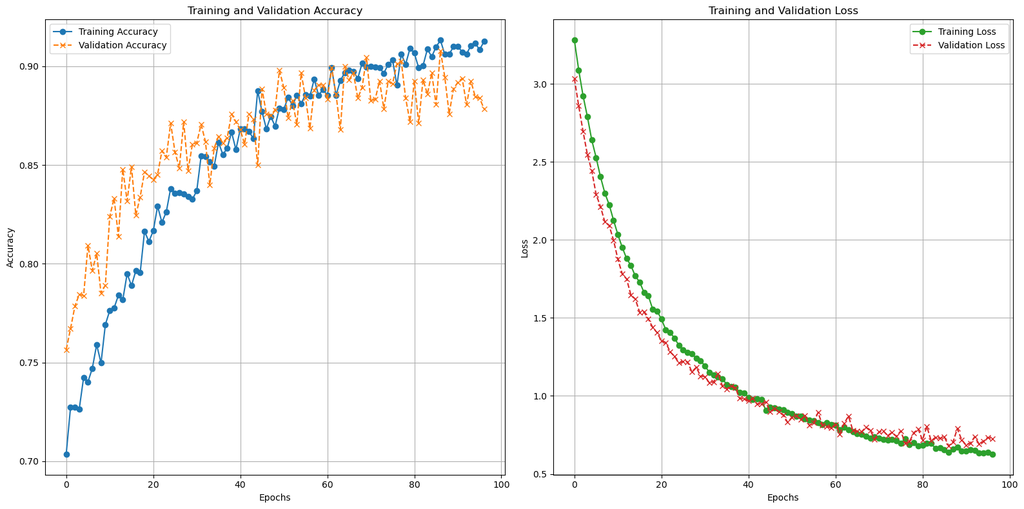

```python
plotValidate(history)
```

Model-2: CNN-LSTM Hybrid Model

```python
from tensorflow.keras.models import Sequential
from tensorflow.keras.layers import Input, Conv1D, MaxPooling1D, LSTM, Dense

# Define the model
model_2 = Sequential()
model_2.add(Input(shape=(X_train.shape[1], 1)))  # Add an Input layer to specify the input shape
model_2.add(Conv1D(64, kernel_size=3, activation='relu'))
model_2.add(BatchNormalization())
model_2.add(MaxPooling1D(pool_size=2))
model_2.add(Dropout(0.3))

model_2.add(LSTM(128, return_sequences=True))
model_2.add(BatchNormalization())
model_2.add(Dropout(0.3))

model_2.add(LSTM(64, return_sequences=False))
model_2.add(BatchNormalization())
model.add(Dropout(0.3))

model_2.add(Dense(128, activation='relu'))
model_2.add(BatchNormalization())
model_2.add(Dropout(0.3))

model_2.add(Dense(64, activation='relu'))
model_2.add(BatchNormalization())
model_2.add(Dropout(0.3))

model_2.add(Dense(10, activation='softmax'))

# Compile the model with a learning rate schedule
lr_schedule = CosineDecay(initial_learning_rate=0.001, decay_steps=1000, alpha=0.1)
optimizer = Adam(learning_rate=lr_schedule)

model_2.compile(optimizer=optimizer, loss="categorical_crossentropy", metrics=["accuracy"])

# Print the model summary
print(model_2.summary())
```

```
Model: "sequential_80"
```

```
┏━━━━━━━━━━━━━━━━━━━━━━━━━━━━━━━━━━━━━━┳━━━━━━━━━━━━━━━━━━━━━━━━━━━━━┳━━━━━━━━━━━━━━━━━┓
┃ Layer (type)                         ┃ Output Shape                ┃         Param # ┃
┡━━━━━━━━━━━━━━━━━━━━━━━━━━━━━━━━━━━━━━╇━━━━━━━━━━━━━━━━━━━━━━━━━━━━━╇━━━━━━━━━━━━━━━━━┩
│ conv1d_6 (Conv1D)                    │ (None, 56, 64)              │             256 │
├──────────────────────────────────────┼─────────────────────────────┼─────────────────┤
│ batch_normalization_20               │ (None, 56, 64)              │             256 │
│ (BatchNormalization)                 │                             │                 │
├──────────────────────────────────────┼─────────────────────────────┼─────────────────┤
│ max_pooling1d_6 (MaxPooling1D)       │ (None, 28, 64)              │               0 │
├──────────────────────────────────────┼─────────────────────────────┼─────────────────┤
│ dropout_286 (Dropout)                │ (None, 28, 64)              │               0 │
├──────────────────────────────────────┼─────────────────────────────┼─────────────────┤
│ lstm_10 (LSTM)                       │ (None, 28, 128)             │          98,816 │
├──────────────────────────────────────┼─────────────────────────────┼─────────────────┤
│ batch_normalization_21               │ (None, 28, 128)             │             512 │
│ (BatchNormalization)                 │                             │                 │
├──────────────────────────────────────┼─────────────────────────────┼─────────────────┤
│ dropout_287 (Dropout)                │ (None, 28, 128)             │               0 │
├──────────────────────────────────────┼─────────────────────────────┼─────────────────┤
│ lstm_11 (LSTM)                       │ (None, 64)                  │          49,408 │
├──────────────────────────────────────┼─────────────────────────────┼─────────────────┤
│ batch_normalization_22               │ (None, 64)                  │             256 │
│ (BatchNormalization)                 │                             │                 │
├──────────────────────────────────────┼─────────────────────────────┼─────────────────┤
│ dense_352 (Dense)                    │ (None, 128)                 │           8,320 │
├──────────────────────────────────────┼─────────────────────────────┼─────────────────┤
│ batch_normalization_23               │ (None, 128)                 │             512 │
│ (BatchNormalization)                 │                             │                 │
├──────────────────────────────────────┼─────────────────────────────┼─────────────────┤
│ dropout_289 (Dropout)                │ (None, 128)                 │               0 │
├──────────────────────────────────────┼─────────────────────────────┼─────────────────┤
│ dense_353 (Dense)                    │ (None, 64)                  │           8,256 │
├──────────────────────────────────────┼─────────────────────────────┼─────────────────┤
│ batch_normalization_24               │ (None, 64)                  │             256 │
│ (BatchNormalization)                 │                             │                 │
├──────────────────────────────────────┼─────────────────────────────┼─────────────────┤
│ dropout_290 (Dropout)                │ (None, 64)                  │               0 │
├──────────────────────────────────────┼─────────────────────────────┼─────────────────┤
│ dense_354 (Dense)                    │ (None, 10)                  │             650 │
└──────────────────────────────────────┴─────────────────────────────┴─────────────────┘
```

```
 Total params: 167,498 (654.29 KB)
```

```
 Trainable params: 166,602 (650.79 KB)
```

```
 Non-trainable params: 896 (3.50 KB)
```

```
None
```

Model-2: Training

```python
# Callbacks for early stopping and model checkpointing
early_stopping = EarlyStopping(monitor='val_loss', patience=20, restore_best_weights=True)
model_checkpoint = ModelCheckpoint('best_model.keras', monitor='val_loss', save_best_only=True)

# Train the model
history = model.fit(X_train_scaled, y_train_onehot,
                    epochs=150,
                    batch_size=64,
                    validation_data=(X_test_scaled, y_test_onehot),
                    callbacks=[early_stopping, model_checkpoint],
                    verbose=1)

# Evaluate the model
test_loss, test_accuracy = model.evaluate(X_test_scaled, y_test_onehot)
print(f"Test Loss: {test_loss:.4f}")
print(f"Test Accuracy: {test_accuracy:.4f}")
```

```
118/118 ━━━━━━━━━━━━━━━━━━━━ 13s 109ms/step - accuracy: 0.7490 - loss: 0.7912 - val_accuracy: 0.7282 - val_loss: 0.8245
118/118 ━━━━━━━━━━━━━━━━━━━━ 13s 108ms/step - accuracy: 0.7370 - loss: 0.8062 - val_accuracy: 0.7302 - val_loss: 0.8258
118/118 ━━━━━━━━━━━━━━━━━━━━ 13s 110ms/step - accuracy: 0.7421 - loss: 0.7907 - val_accuracy: 0.7358 - val_loss: 0.8178
118/118 ━━━━━━━━━━━━━━━━━━━━ 13s 109ms/step - accuracy: 0.7455 - loss: 0.7622 - val_accuracy: 0.7278 - val_loss: 0.8258
118/118 ━━━━━━━━━━━━━━━━━━━━ 13s 112ms/step - accuracy: 0.7472 - loss: 0.7852 - val_accuracy: 0.7274 - val_loss: 0.8289
118/118 ━━━━━━━━━━━━━━━━━━━━ 14s 115ms/step - accuracy: 0.7416 - loss: 0.7746 - val_accuracy: 0.7358 - val_loss: 0.8200
118/118 ━━━━━━━━━━━━━━━━━━━━ 12s 100ms/step - accuracy: 0.7437 - loss: 0.7704 - val_accuracy: 0.7342 - val_loss: 0.8081
118/118 ━━━━━━━━━━━━━━━━━━━━ 13s 110ms/step - accuracy: 0.7519 - loss: 0.7491 - val_accuracy: 0.7358 - val_loss: 0.8030
118/118 ━━━━━━━━━━━━━━━━━━━━ 14s 119ms/step - accuracy: 0.7502 - loss: 0.7562 - val_accuracy: 0.7274 - val_loss: 0.8293
118/118 ━━━━━━━━━━━━━━━━━━━━ 12s 104ms/step - accuracy: 0.7269 - loss: 0.8052 - val_accuracy: 0.7266 - val_loss: 0.8177
118/118 ━━━━━━━━━━━━━━━━━━━━ 13s 105ms/step - accuracy: 0.7528 - loss: 0.7470 - val_accuracy: 0.7462 - val_loss: 0.8031
118/118 ━━━━━━━━━━━━━━━━━━━━ 12s 102ms/step - accuracy: 0.7634 - loss: 0.7377 - val_accuracy: 0.7398 - val_loss: 0.8105
118/118 ━━━━━━━━━━━━━━━━━━━━ 12s 99ms/step - accuracy: 0.7543 - loss: 0.7384 - val_accuracy: 0.7378 - val_loss: 0.8116
118/118 ━━━━━━━━━━━━━━━━━━━━ 12s 102ms/step - accuracy: 0.7583 - loss: 0.7398 - val_accuracy: 0.7386 - val_loss: 0.8045
118/118 ━━━━━━━━━━━━━━━━━━━━ 12s 105ms/step - accuracy: 0.7601 - loss: 0.7281 - val_accuracy: 0.7330 - val_loss: 0.8129
118/118 ━━━━━━━━━━━━━━━━━━━━ 12s 103ms/step - accuracy: 0.7588 - loss: 0.7342 - val_accuracy: 0.7414 - val_loss: 0.8036
118/118 ━━━━━━━━━━━━━━━━━━━━ 12s 102ms/step - accuracy: 0.7658 - loss: 0.7137 - val_accuracy: 0.7410 - val_loss: 0.8060
118/118 ━━━━━━━━━━━━━━━━━━━━ 12s 102ms/step - accuracy: 0.7527 - loss: 0.7387 - val_accuracy: 0.7386 - val_loss: 0.8000
118/118 ━━━━━━━━━━━━━━━━━━━━ 12s 102ms/step - accuracy: 0.7665 - loss: 0.7116 - val_accuracy: 0.7398 - val_loss: 0.7956
118/118 ━━━━━━━━━━━━━━━━━━━━ 13s 109ms/step - accuracy: 0.7663 - loss: 0.7095 - val_accuracy: 0.7450 - val_loss: 0.7965
118/118 ━━━━━━━━━━━━━━━━━━━━ 13s 108ms/step - accuracy: 0.7627 - loss: 0.7029 - val_accuracy: 0.7406 - val_loss: 0.8079
118/118 ━━━━━━━━━━━━━━━━━━━━ 13s 106ms/step - accuracy: 0.7610 - loss: 0.6984 - val_accuracy: 0.7406 - val_loss: 0.7945
118/118 ━━━━━━━━━━━━━━━━━━━━ 12s 100ms/step - accuracy: 0.7640 - loss: 0.7118 - val_accuracy: 0.7402 - val_loss: 0.7955
118/118 ━━━━━━━━━━━━━━━━━━━━ 12s 102ms/step - accuracy: 0.7648 - loss: 0.7109 - val_accuracy: 0.7438 - val_loss: 0.7937
118/118 ━━━━━━━━━━━━━━━━━━━━ 13s 108ms/step - accuracy: 0.7548 - loss: 0.7278 - val_accuracy: 0.7382 - val_loss: 0.7985
118/118 ━━━━━━━━━━━━━━━━━━━━ 13s 107ms/step - accuracy: 0.7836 - loss: 0.6635 - val_accuracy: 0.7478 - val_loss: 0.7882
118/118 ━━━━━━━━━━━━━━━━━━━━ 13s 109ms/step - accuracy: 0.7758 - loss: 0.6759 - val_accuracy: 0.7454 - val_loss: 0.7895
118/118 ━━━━━━━━━━━━━━━━━━━━ 13s 108ms/step - accuracy: 0.7677 - loss: 0.6954 - val_accuracy: 0.7458 - val_loss: 0.8005
118/118 ━━━━━━━━━━━━━━━━━━━━ 13s 109ms/step - accuracy: 0.7653 - loss: 0.6902 - val_accuracy: 0.7446 - val_loss: 0.7951
118/118 ━━━━━━━━━━━━━━━━━━━━ 13s 106ms/step - accuracy: 0.7708 - loss: 0.6840 - val_accuracy: 0.7494 - val_loss: 0.7817
118/118 ━━━━━━━━━━━━━━━━━━━━ 12s 105ms/step - accuracy: 0.7805 - loss: 0.6775 - val_accuracy: 0.7490 - val_loss: 0.7952
118/118 ━━━━━━━━━━━━━━━━━━━━ 13s 110ms/step - accuracy: 0.7845 - loss: 0.6605 - val_accuracy: 0.7402 - val_loss: 0.8018
118/118 ━━━━━━━━━━━━━━━━━━━━ 12s 100ms/step - accuracy: 0.7695 - loss: 0.6815 - val_accuracy: 0.7434 - val_loss: 0.7996
118/118 ━━━━━━━━━━━━━━━━━━━━ 13s 107ms/step - accuracy: 0.7788 - loss: 0.6655 - val_accuracy: 0.7462 - val_loss: 0.7832
118/118 ━━━━━━━━━━━━━━━━━━━━ 12s 105ms/step - accuracy: 0.7768 - loss: 0.6659 - val_accuracy: 0.7554 - val_loss: 0.7782
118/118 ━━━━━━━━━━━━━━━━━━━━ 12s 105ms/step - accuracy: 0.7854 - loss: 0.6550 - val_accuracy: 0.7550 - val_loss: 0.7678
118/118 ━━━━━━━━━━━━━━━━━━━━ 13s 110ms/step - accuracy: 0.7834 - loss: 0.6481 - val_accuracy: 0.7486 - val_loss: 0.7896
118/118 ━━━━━━━━━━━━━━━━━━━━ 12s 105ms/step - accuracy: 0.7853 - loss: 0.6556 - val_accuracy: 0.7530 - val_loss: 0.7829
118/118 ━━━━━━━━━━━━━━━━━━━━ 13s 107ms/step - accuracy: 0.7816 - loss: 0.6602 - val_accuracy: 0.7518 - val_loss: 0.7695
118/118 ━━━━━━━━━━━━━━━━━━━━ 13s 106ms/step - accuracy: 0.7916 - loss: 0.6398 - val_accuracy: 0.7510 - val_loss: 0.7758
```

[output cut: 44 more lines]

```
118/118 ━━━━━━━━━━━━━━━━━━━━ 14s 116ms/step - accuracy: 0.8250 - loss: 0.5170 - val_accuracy: 0.7706 - val_loss: 0.7598
118/118 ━━━━━━━━━━━━━━━━━━━━ 14s 118ms/step - accuracy: 0.8228 - loss: 0.5318 - val_accuracy: 0.7746 - val_loss: 0.7448
118/118 ━━━━━━━━━━━━━━━━━━━━ 14s 119ms/step - accuracy: 0.8254 - loss: 0.5119 - val_accuracy: 0.7674 - val_loss: 0.7634
118/118 ━━━━━━━━━━━━━━━━━━━━ 13s 106ms/step - accuracy: 0.8271 - loss: 0.5267 - val_accuracy: 0.7742 - val_loss: 0.7606
118/118 ━━━━━━━━━━━━━━━━━━━━ 13s 106ms/step - accuracy: 0.8375 - loss: 0.5135 - val_accuracy: 0.7814 - val_loss: 0.7443
118/118 ━━━━━━━━━━━━━━━━━━━━ 14s 115ms/step - accuracy: 0.8333 - loss: 0.5082 - val_accuracy: 0.7814 - val_loss: 0.7607
118/118 ━━━━━━━━━━━━━━━━━━━━ 13s 113ms/step - accuracy: 0.8390 - loss: 0.5195 - val_accuracy: 0.7850 - val_loss: 0.7421
118/118 ━━━━━━━━━━━━━━━━━━━━ 14s 115ms/step - accuracy: 0.8308 - loss: 0.5108 - val_accuracy: 0.7818 - val_loss: 0.7526
118/118 ━━━━━━━━━━━━━━━━━━━━ 14s 118ms/step - accuracy: 0.8289 - loss: 0.5058 - val_accuracy: 0.7798 - val_loss: 0.7530
118/118 ━━━━━━━━━━━━━━━━━━━━ 14s 114ms/step - accuracy: 0.8369 - loss: 0.5003 - val_accuracy: 0.7786 - val_loss: 0.7502
118/118 ━━━━━━━━━━━━━━━━━━━━ 13s 108ms/step - accuracy: 0.8315 - loss: 0.5033 - val_accuracy: 0.7738 - val_loss: 0.7693
118/118 ━━━━━━━━━━━━━━━━━━━━ 13s 106ms/step - accuracy: 0.8200 - loss: 0.5256 - val_accuracy: 0.7834 - val_loss: 0.7564
79/79 ━━━━━━━━━━━━━━━━━━━━ 2s 29ms/step - accuracy: 0.7660 - loss: 0.7590
Test Loss: 0.7365
Test Accuracy: 0.7762
```

Model-2: Plotting

```
Best Validation Accuracy: 0.7850280404090881
```

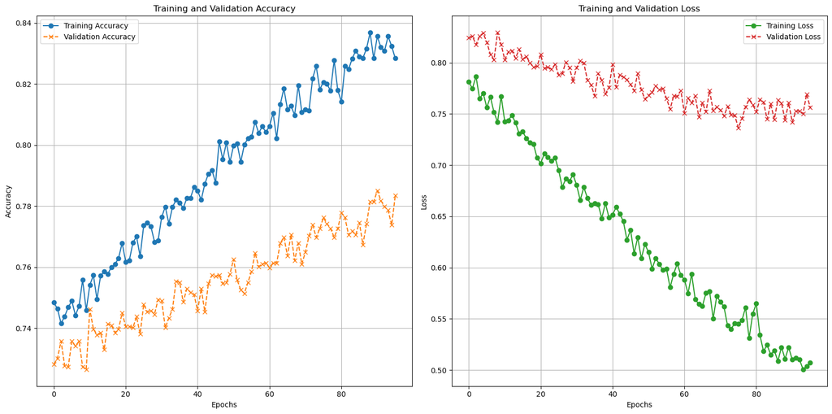

```python
plotValidate(history)
```

🏆 Model Evaluation 🎯

Model-1: Predictions

As The first Mdoel has higher test accuracy ihave selected it for further evaluation and predictions

```python
# Make predictions on the test set
predictions_one_hot = model.predict(X_test)

# Convert one-hot encoded predictions to class labels
predictions = np.argmax(predictions_one_hot, axis=1)

# Convert one-hot encoded actual labels back to class labels
actual_labels = np.argmax(y_test_one_hot, axis=1)

# Compare predictions with actual labels
accuracy = accuracy_score(actual_labels, predictions)

# Print predictions and accuracy
print("Sample Predictions:", predictions[:5])
print("Actual Labels:", actual_labels[:5])
print(f'Accuracy: {accuracy:.4f}')
```

```
79/79 ━━━━━━━━━━━━━━━━━━━━ 2s 13ms/step
Sample Predictions: [4 5 0 2 6]
Actual Labels: [4 5 0 0 6]
Accuracy: 0.9151
```

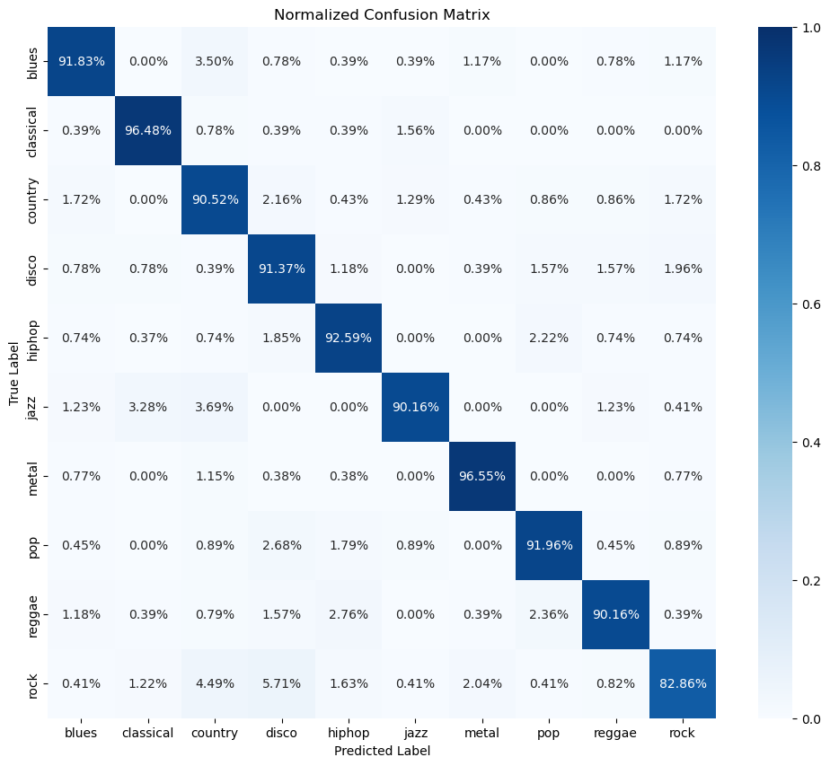

```python
from sklearn.metrics import confusion_matrix, classification_report

# Compute the confusion matrix
cm = confusion_matrix(actual_labels, predictions)

# Normalize the confusion matrix
cm_normalized = cm.astype(float) / cm.sum(axis=1)[:, np.newaxis]

# Plot the confusion matrix
plt.figure(figsize=(12, 10))
sns.heatmap(cm_normalized, annot=True, fmt='.2%', cmap='Blues', cbar=True,
            xticklabels=label_encoder.classes_,
            yticklabels=label_encoder.classes_,
            vmin=0, vmax=1)

plt.xlabel('Predicted Label')
plt.ylabel('True Label')
plt.title('Normalized Confusion Matrix')
plt.show()
```

```python
from sklearn.metrics import classification_report

# Generate classification report
report = classification_report(actual_labels, predictions, target_names=label_encoder.classes_, output_dict=True)

# Convert classification report to DataFrame
report_df = pd.DataFrame(report).transpose()

# Print the classification report table
print("Classification Report:\n")
report_df
```

```
Classification Report:
```

|  | precision | recall | f1-score | support |
| --- | --- | --- | --- | --- |
| blues | 0.925490 | 0.918288 | 0.921875 | 257.000000 |
| classical | 0.942748 | 0.964844 | 0.953668 | 256.000000 |
| country | 0.836653 | 0.905172 | 0.869565 | 232.000000 |
| disco | 0.859779 | 0.913725 | 0.885932 | 255.000000 |
| hiphop | 0.919118 | 0.925926 | 0.922509 | 270.000000 |
| jazz | 0.952381 | 0.901639 | 0.926316 | 244.000000 |
| metal | 0.958175 | 0.965517 | 0.961832 | 261.000000 |
| pop | 0.915556 | 0.919643 | 0.917595 | 224.000000 |
| reggae | 0.934694 | 0.901575 | 0.917836 | 254.000000 |
| rock | 0.910314 | 0.828571 | 0.867521 | 245.000000 |
| accuracy | 0.915132 | 0.915132 | 0.915132 | 0.915132 |
| macro avg | 0.915491 | 0.914490 | 0.914465 | 2498.000000 |
| weighted avg | 0.916210 | 0.915132 | 0.915158 | 2498.000000 |

```python
from sklearn.linear_model import LogisticRegression
from sklearn.metrics import accuracy_score, classification_report, confusion_matrix
import seaborn as sns
import matplotlib.pyplot as plt
import pandas as pd

# Initialize the Logistic Regression model with specific parameter values
log_reg = LogisticRegression(
    penalty='l2',            # Regularization type ('l1', 'l2', 'elasticnet', or None)
    C=100,                   # Inverse of regularization strength; smaller values specify stronger regularization     # Algorithm to use for optimization ('newton-cg', 'lbfgs', 'liblinear', 'saga')
    max_iter=1500,
    solver = 'lbfgs',# Maximum number of iterations for the solver to converge
    random_state=42,         # Seed for random number generator to ensure reproducibility     # Multi-class handling strategy ('auto', 'ovr', 'multinomial')
    class_weight='balanced'  # Weight class labels based on their frequencies in the data
)
log_reg.fit(X_train_scaled, y_train_encoded)

# Predict and evaluate
y_pred_log_reg = log_reg.predict(X_test_scaled)
accuracy_log_reg = accuracy_score(y_test_encoded, y_pred_log_reg)
print(accuracy_log_reg)
```

```
0.7389911929543634
```

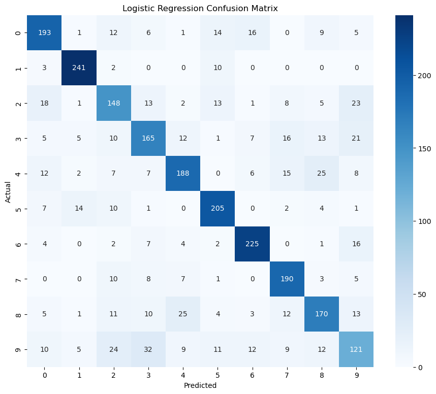

```python
# Confusion Matrix
conf_matrix_log_reg = confusion_matrix(y_test_encoded, y_pred_log_reg)
classification_report_log_reg = classification_report(y_test_encoded, y_pred_log_reg, output_dict=True)


# Visualization
plt.figure(figsize=(11, 9))
sns.heatmap(conf_matrix_log_reg, annot=True, fmt='d', cmap='Blues')
plt.title('Logistic Regression Confusion Matrix')
plt.xlabel('Predicted')
plt.ylabel('Actual')
plt.show()
```

```python
# Print results
print(f"Logistic Regression Accuracy: {accuracy_log_reg:.4f}")
print("Classification Report for Logistic Regression:")
df_classification_report_log_reg = pd.DataFrame(classification_report_log_reg).transpose()
df_classification_report_log_reg.head(3)
```

```
Logistic Regression Accuracy: 0.7390
Classification Report for Logistic Regression:
```

|  | precision | recall | f1-score | support |
| --- | --- | --- | --- | --- |
| 0 | 0.750973 | 0.750973 | 0.750973 | 257.0 |
| 1 | 0.892593 | 0.941406 | 0.916350 | 256.0 |
| 2 | 0.627119 | 0.637931 | 0.632479 | 232.0 |

```python
# Create DataFrame for better visualization (optional)
df_predictions = pd.DataFrame({
    'Actual': y_test_encoded,
    'Predicted': y_pred_log_reg
})
df_predictions.head(4)
```

|  | Actual | Predicted |
| --- | --- | --- |
| 0 | 4 | 0 |
| 1 | 5 | 5 |
| 2 | 0 | 0 |
| 3 | 0 | 0 |

```python
from sklearn.svm import SVC

from sklearn.svm import SVC

# Initialize the SVM model with specific parameters
svm_model = SVC(
    C=150,                   # Regularization parameter
    kernel='rbf',            # Kernel type
    degree=3,                # Degree of polynomial kernel (if applicable)
    gamma='scale',           # Kernel coefficient
    coef0=1,               # Independent term in kernel function
    shrinking=False,          # Whether to use the shrinking heuristic
    probability=False,       # Whether to enable probability estimates
    class_weight='balanced', # Class weights
    decision_function_shape='ovo', # Shape of decision function
    random_state=42          # Seed for random number generator
)

# Fit the model
svm_model.fit(X_train_scaled, y_train_encoded)

# Predict and evaluate
y_pred_svm = svm_model.predict(X_test_scaled)
accuracy_svm = accuracy_score(y_test_encoded, y_pred_svm)
print(f"Accuracy: {accuracy_svm}")
```

```
Accuracy: 0.9055244195356285
```

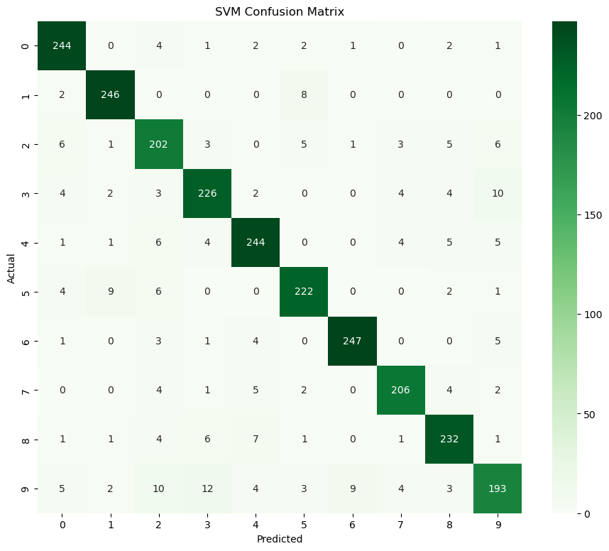

```python
# Predict and evaluate
y_pred_svm = svm_model.predict(X_test_scaled)
accuracy_svm = accuracy_score(y_test_encoded, y_pred_svm)
classification_report_svm = classification_report(y_test_encoded, y_pred_svm, output_dict=True)

# Confusion Matrix
conf_matrix_svm = confusion_matrix(y_test_encoded, y_pred_svm)

# Visualization
plt.figure(figsize=(11, 9))
sns.heatmap(conf_matrix_svm, annot=True, fmt='d', cmap='Greens')
plt.title('SVM Confusion Matrix')
plt.xlabel('Predicted')
plt.ylabel('Actual')
plt.show()
```

```python
# Print results
print(f"SVM Accuracy: {accuracy_svm:.4f}")
print("Classification Report for SVM:")
df_classification_report_svm = pd.DataFrame(classification_report_svm).transpose()
df_classification_report_svm.head(3)
```

```
SVM Accuracy: 0.9055
Classification Report for SVM:
```

|  | precision | recall | f1-score | support |
| --- | --- | --- | --- | --- |
| 0 | 0.910448 | 0.949416 | 0.929524 | 257.0 |
| 1 | 0.938931 | 0.960938 | 0.949807 | 256.0 |
| 2 | 0.834711 | 0.870690 | 0.852321 | 232.0 |

```python
# Create DataFrame for better visualization (optional)
df_predictions = pd.DataFrame({
    'Actual': y_test_encoded,
    'Predicted': y_pred_svm
})
df_predictions.head(4)
```

|  | Actual | Predicted |
| --- | --- | --- |
| 0 | 4 | 4 |
| 1 | 5 | 5 |
| 2 | 0 | 0 |
| 3 | 0 | 0 |

```python
from sklearn.tree import DecisionTreeClassifier

# Initialize the decision tree model with specific parameters
tree_model = DecisionTreeClassifier(
    criterion='entropy',                # Function to measure the quality of a split
    splitter='best',                 # Strategy to choose the split at each node
    max_depth=100,                    # Maximum depth of the tree
    min_samples_split=3,             # Minimum number of samples required to split an internal node
    min_samples_leaf=5,              # Minimum number of samples required to be at a leaf node
    max_features=150,             # Number of features to consider when looking for the best split
    max_leaf_nodes=700,               # Maximum number of leaf nodes
    min_impurity_decrease=0.001,      # Minimum impurity decrease required to split a node
    class_weight='balanced',         # Weights associated with classes
    random_state=0                  # Seed for the random number generator
)

# Fit the model
tree_model.fit(X_train_scaled, y_train_encoded)

# Predict and evaluate
y_pred_tree = tree_model.predict(X_test_scaled)
accuracy_tree = accuracy_score(y_test_encoded, y_pred_tree)
print(f"Accuracy: {accuracy_tree}")


# Predict and evaluate
y_pred_tree = tree_model.predict(X_test_scaled)
accuracy_tree = accuracy_score(y_test_encoded, y_pred_tree)
print(f"Decision Tree Accuracy: {accuracy_tree:.4f}")
```

```
Accuracy: 0.6717373899119295
Decision Tree Accuracy: 0.6717
```

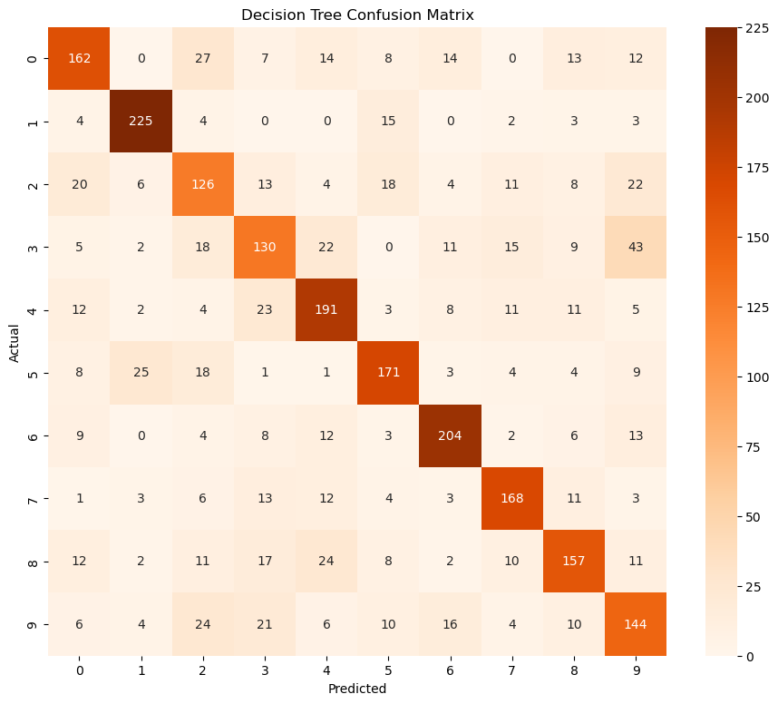

```python
classification_report_tree = classification_report(y_test_encoded, y_pred_tree, output_dict=True)

# Confusion Matrix
conf_matrix_tree = confusion_matrix(y_test_encoded, y_pred_tree)

# Visualization
plt.figure(figsize=(11, 9))
sns.heatmap(conf_matrix_tree, annot=True, fmt='d', cmap='Oranges')
plt.title('Decision Tree Confusion Matrix')
plt.xlabel('Predicted')
plt.ylabel('Actual')
plt.show()
```

```python
print(f"Decision Tree Accuracy: {accuracy_tree:.4f}")
print("Classification Report for Decision Tree:")
df_classification_report_tree = pd.DataFrame(classification_report_tree).transpose()
df_classification_report_tree.head(3)
```

```
Decision Tree Accuracy: 0.6717
Classification Report for Decision Tree:
```

|  | precision | recall | f1-score | support |
| --- | --- | --- | --- | --- |
| 0 | 0.677824 | 0.630350 | 0.653226 | 257.0 |
| 1 | 0.836431 | 0.878906 | 0.857143 | 256.0 |
| 2 | 0.520661 | 0.543103 | 0.531646 | 232.0 |

```python
# Create DataFrame for better visualization (optional)
df_predictions = pd.DataFrame({
    'Actual': y_test_encoded,
    'Predicted': y_pred_tree
})
df_predictions.head(4)
```

|  | Actual | Predicted |
| --- | --- | --- |
| 0 | 4 | 4 |
| 1 | 5 | 5 |
| 2 | 0 | 6 |
| 3 | 0 | 0 |

```python
# Create a summary table
summary_data = {
    "Model": ["Logistic Regression", "SVM", "Decision Tree"],
    "Accuracy": [accuracy_log_reg, accuracy_svm, accuracy_tree]
}

summary_df = pd.DataFrame(summary_data)
print("Model Performance Summary:")
summary_df
```

```
Model Performance Summary:
```

|  | Model | Accuracy |
| --- | --- | --- |
| 0 | Logistic Regression | 0.738991 |
| 1 | SVM | 0.905524 |
| 2 | Decision Tree | 0.671737 |

```python
# Accuracy values for the models
accuracy_log_reg = 0.738991
accuracy_svm = 0.905524
accuracy_tree = 0.671737
accuracy_fc_nn = 0.9151  # Fully Connected Neural Network
accuracy_lstm_cnn = 0.7762  # LSTM-CNN Model

# Create a summary table
summary_data = {
    "Model": ["Logistic Regression", "SVM", "Decision Tree", "Fully Connected Neural Network", "LSTM-CNN"],
    "Accuracy": [accuracy_log_reg, accuracy_svm, accuracy_tree, accuracy_fc_nn, accuracy_lstm_cnn]
}

# Convert to DataFrame
summary_df = pd.DataFrame(summary_data)

# Determine the winner
winner = summary_df.loc[summary_df['Accuracy'].idxmax(), 'Model']

# Add a 'Winner' column to the DataFrame
summary_df['Winner'] = summary_df['Model'].apply(lambda x: 'Yes' if x == winner else 'No')

# Print the summary table
print("Model Performance Summary:")
summary_df
```

```
Model Performance Summary:
```

|  | Model | Accuracy | Winner |
| --- | --- | --- | --- |
| 0 | Logistic Regression | 0.738991 | No |
| 1 | SVM | 0.905524 | No |
| 2 | Decision Tree | 0.671737 | No |
| 3 | Fully Connected Neural Network | 0.915100 | Yes |
| 4 | LSTM-CNN | 0.776200 | No |